# Анализ портфеля из индекса ММВБ и одногодичными ОФЗ

Андрюничев Валера.

6 февраля 2019 г

Установка рабочей дериктории:

```r
setwd('D:/GH/Share and bonds')
```

Загрузка библиотек:

```r
library(ggplot2)
library(reshape2)
library(xts)
library(ggthemes)
library(formattable)
```

Загрузка и обработка данных:

```r
moex <- read.csv('Прошлые данные - Индекс МосБиржи.csv', encoding="UTF-8")
moex <- data.frame('Year' = moex$X.U.FEFF.Дата, 'Price' = moex$Изм...)
moex <- tidyr::separate(data = moex, col = Year, c('Month', 'Year'))
moex <- moex[,-1]
bond <- read.csv('Прошлые данные доходности облигаций Россия годовые.csv', encoding="UTF-8")
bond <- data.frame('Year' = bond$X.U.FEFF.Дата, 'Incom' = bond$Цена)
bond <- tidyr::separate(data = bond, col = Year,c('Month', 'Year'))
bond <- bond[,-1]
bond <- bond[rev(rownames(bond)),]

data <- data.frame('Year' = moex$Year, 'MOEX' = moex$Price, 'Bond' = bond$Incom)
data$MOEX <- gsub(pattern = '%', '', data$MOEX)
data$MOEX <- gsub(pattern = ',', '.', data$MOEX)
data$Bond <- gsub(pattern = ',', '.', data$Bond)
data$MOEX <- as.numeric(data$MOEX);class(data$MOEX)
```

```
## [1] "numeric"
```

```r
data$Bond <- as.numeric(data$Bond);class(data$Bond)
```

```
## [1] "numeric"
```

```r
data$Bond <- data$Bond / 12
head(data)
```

```
##   Year   MOEX      Bond
## 1   04   7.19 0.2214167
## 2   04   7.14 0.3185833
## 3   04   9.06 0.2681667
## 4   04 -12.85 0.4535000
## 5   04  -4.70 0.4666667
## 6   04  -0.10 0.4155833
```

Построим графи к сравнения доходности индекса акций и облигаций:

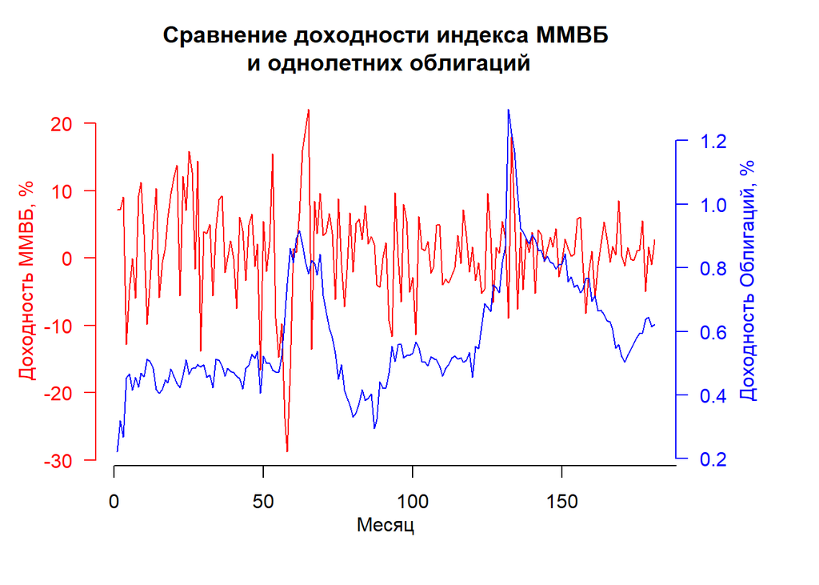

```r
par(mar=c(5, 4, 4, 6) + 0.1)
plot(data$MOEX, type = 'l', col = 'red', axes = FALSE,
     main = 'Сравнение доходности индекса ММВБ\n и однолетних облигаций', xlab = "", ylab = "")
axis(2, ylim = c(-30, 30), col = "red", col.axis = 'red', las = 1)
mtext("Доходность ММВБ, %", col = 'red', side = 2, line = 2.5)
par(new = TRUE)
plot(data$Bond, type = 'l', col = 'blue', axes = FALSE, xlab="", ylab="")
axis(4, ylim = c(0, 3), col = "blue", col.axis = "blue", las = 1)
mtext("Доходность Облигаций, %", side = 4, col = "blue", line = 2.5)
axis(1, pretty(index(data)))
mtext("Месяц", side = 1, col = "black", line = 2)
```

По графику видно, что индекс показывает значительно большую доходность и волатильность в сравнении с облигациями

Посмотрим на коэффициенты прироста капитала:

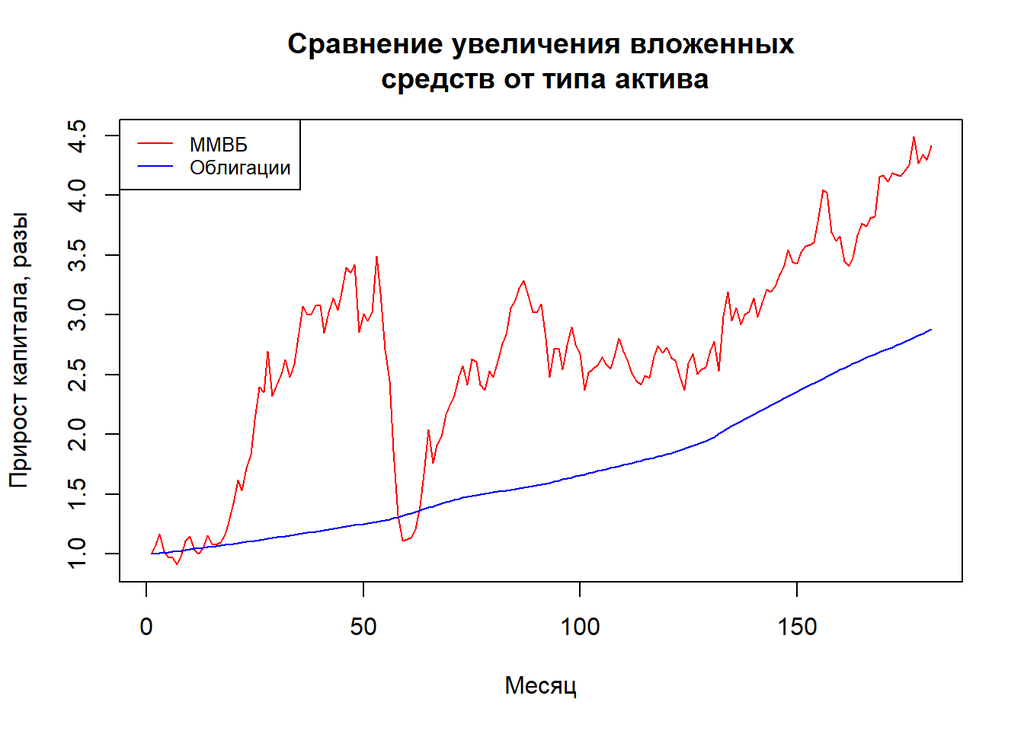

```r
data$Moex_add <- 1
data$Bond_add <- 1

N <- nrow(data)
for (i in 2:N) {
  data$Moex_add[i] = data$Moex_add[i-1] *(1 + (data$MOEX[i] / 100))
  data$Bond_add[i] = data$Bond_add[i-1] *(1 + (data$Bond[i] / 100))
}

plot(data$Moex_add, type = 'l', col = 'red',
     main = 'Сравнение увеличения вложенных\n средств от типа актива', xlab = 'Месяц',
     ylab = 'Прирост капитала, разы')
lines(data$Bond_add, col = 'blue')
legend("topleft", c("ММВБ","Облигации"), cex=.8, col = c("red", "blue"), lty = c(1, 1))
```

Индекс показывает больший прирост капитала чем облигации.

Создадим портфель из 80% Индекса Акций и 20% индекса облигаций:

```r
portfolio <- 100000  # Сумма портфеля
Risk <- .8 # Доля рисковой части
No_Risk <- 1 - Risk # Доля безрисковой
portfolio_a <- portfolio * Risk
portfolio_p <- portfolio * No_Risk
data$P_M <- data$Moex_add * portfolio_a
data$P_B <- data$Bond_add * portfolio_p
data$Sum <- data$P_M + data$P_B
data$MoexWeight <- data$P_M / data$Sum
data$BondWeight <- data$P_B / data$Sum
data$vanilaMoex <- data$Moex_add * portfolio
data$vanilaBond <- data$Bond_add * portfolio
head(data)
```

```
##   Year   MOEX      Bond  Moex_add Bond_add      P_M      P_B       Sum
## 1   04   7.19 0.2214167 1.0000000 1.000000 80000.00 20000.00 100000.00
## 2   04   7.14 0.3185833 1.0714000 1.003186 85712.00 20063.72 105775.72
## 3   04   9.06 0.2681667 1.1684688 1.005876 93477.51 20117.52 113595.03
## 4   04 -12.85 0.4535000 1.0183206 1.010438 81465.65 20208.75 101674.40
## 5   04  -4.70 0.4666667 0.9704595 1.015153 77636.76 20303.06  97939.82
## 6   04  -0.10 0.4155833 0.9694891 1.019372 77559.13 20387.44  97946.56
##   MoexWeight BondWeight vanilaMoex vanilaBond
## 1  0.8000000  0.2000000  100000.00   100000.0
## 2  0.8103183  0.1896817  107140.00   100318.6
## 3  0.8229014  0.1770986  116846.88   100587.6
## 4  0.8012405  0.1987595  101832.06   101043.8
## 5  0.7926986  0.2073014   97045.95   101515.3
## 6  0.7918514  0.2081486   96948.91   101937.2
```

Посмотрим на состав портфеля по годам:

```r
temp <- data[,c(1,9,10)];colnames(temp) <- c('Year', 'Moex', 'Bond')
temp <- temp[seq(1, nrow(temp), 12), ]
temp <- temp[,c(1,3,2)]
portfel <- melt(temp)
head(portfel)
```

```
##   Year variable      value
## 1   04     Bond 0.20000000
## 2   05     Bond 0.20153239
## 3   06     Bond 0.11571482
## 4   07     Bond 0.08924865
## 5   08     Bond 0.09844085
## 6   09     Bond 0.22851860
```

```r
rm(a,b,temp)
```

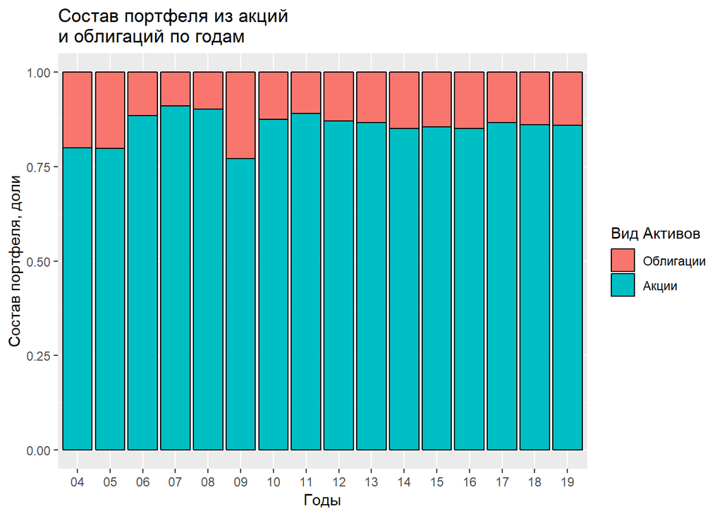

```r
ggplot(portfel, aes(x = portfel$Year, y = portfel$value, fill = portfel$variable)) +
  geom_bar(stat = "identity", colour = 'black')+
  xlab("Годы")+
  ylab("Состав портфеля, доли")+
  scale_fill_discrete(name='Вид Активов',labels=c('Облигации', 'Акции'))+
  ggtitle(label = 'Состав портфеля из акций\nи облигаций по годам')
```

Посмотрим на результат стратегии:

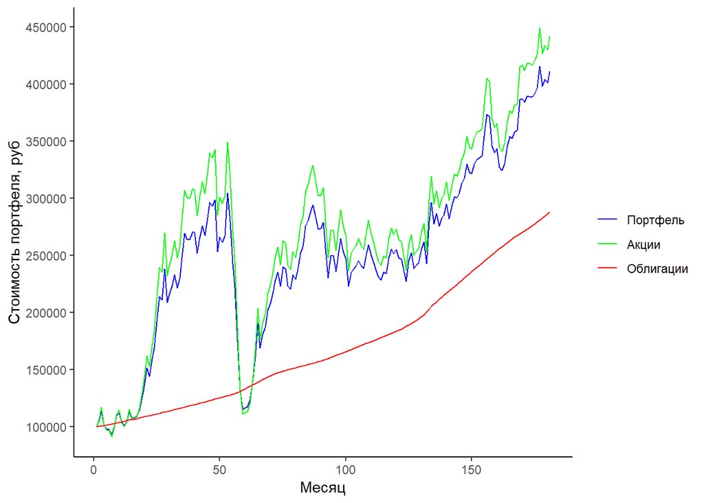

```r
result <- data[,c(8,11,12)]
colnames(result) <- c('Portfolio', 'MOEX', 'Bond')
ggplot(result, aes(x = index(result)))+
  geom_line(aes(y = result$Portfolio, colour = 'Portfolio'))+
  geom_line(aes(y = result$MOEX, colour = 'MOEX'))+
  geom_line(aes(y = result$Bond, colour = 'Bond'))+
  xlab("Месяц")+
  ylab("Стоимость портфеля, руб")+
  scale_colour_manual("",
    breaks = c('Portfolio', 'MOEX', 'Bond'),values = c("red", "green", "blue"),
    labels=c('Портфель', 'Акции', 'Облигации'))+
  scale_y_continuous(breaks=seq(0, 500000, 50000))+
  theme_classic()
```

На выбранном промежутке стоимость портфеля состоящего только из акции в конечном итоге покажет болшую доходность чем портфель.

### Построим стратеги с использование ребалансировок

Рассчитаем стратегию с ребалансировкой раз в год:

```r
df <- data[,-c(4:5)]
df$Signal <- 0
N <- nrow(df)
for (i in 2:N) {df$Signal[i] = ifelse(df$Year[i] == df$Year[i-1], 0, 1)}
df$MOEX <- df$MOEX / 100
df$Bond <- df$Bond / 100
for (i in 2:N){
  if(df$Signal[i] == 1){
    df$P_M[i] = df$P_M[i-1] * (1 + df$MOEX[i])
    df$P_B[i] = df$P_B[i-1] * (1 + df$Bond[i])
    df$P_M[i] = df$Sum[i] * Risk
    df$P_B[i] = df$Sum[i] * No_Risk
    df$MoexWeight[i] = df$P_M[i] / df$Sum[i]
    df$BondWeight[i] = df$P_B[i] / df$Sum[i]
  } else {
    df$P_M[i] = df$P_M[i-1] * (1 + df$MOEX[i])
    df$P_B[i] = df$P_B[i-1] * (1 + df$Bond[i])
    df$Sum[i] = df$P_M[i] + df$P_B[i]
    df$MoexWeight[i] = df$P_M[i] / df$Sum[i]
    df$BondWeight[i] = df$P_B[i] / df$Sum[i]
  }
}
```

Посмотрим на результат

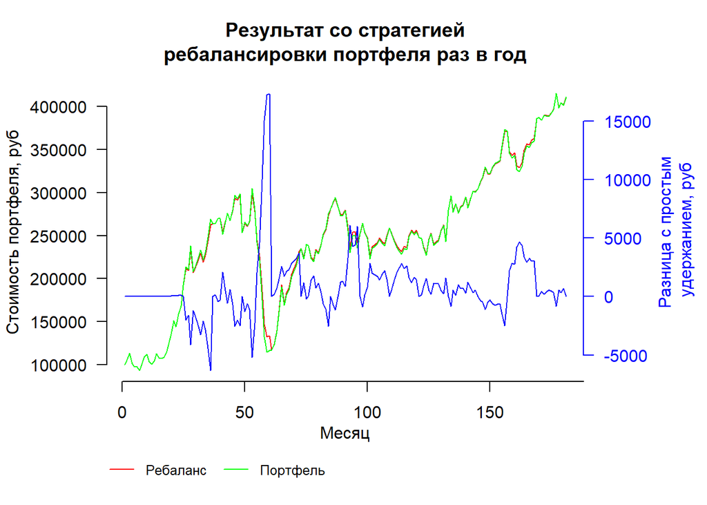

```r
result_r <- data.frame('Reb'= df[,6])
result_r$Vanila <- result$Portfolio
result_r$diff <- result_r$Reb - result_r$Vanila

par(mar=c(6, 5.2, 4, 6) + 0.1)
plot(result_r$Reb, type = 'l', col = 'red', axes = FALSE,
     main = 'Результат со стратегией\nребалансировки портфеля раз в год', xlab = "", ylab = "")
lines(result_r$Vanila, col = 'green')
axis(2, ylim = c(0, 500000), col = "black", col.axis = 'black', las = 1)
mtext("Стоимость портфеля, руб", side = 2, col = "black", line = 4.2)
par(new = TRUE)
plot(result_r$diff, type = 'l', col = 'blue', axes = FALSE, xlab="", ylab="")
axis(4, ylim = c(-16000, 16000), col = "blue", col.axis = "blue", las = 1)
mtext("Разница с простым\n удержанием, руб", side = 4, col = "blue", line = 4.5)
axis(1, pretty(index(result_r)))
mtext("Месяц", side = 1, col = "black", line = 2)
legend(x = -10, y = -13400, c("Ребаланс","Портфель"), cex=.8, col = c("red", "green"),
       lty = c(1, 1), box.lty=0,inset=c(0,1), xpd=TRUE, horiz=TRUE)
```

Рассчитаем стратегию с ребалансировкой раз в квартал:

```r
df <- data[,-c(4:5)]
df$Signal <- 0
df[seq(1, nrow(df), 4), 11] <- 1
df$MOEX <- df$MOEX / 100
df$Bond <- df$Bond / 100
for (i in 2:N){
  if(df$Signal[i] == 1){
    df$P_M[i] = df$P_M[i-1] * (1 + df$MOEX[i])
    df$P_B[i] = df$P_B[i-1] * (1 + df$Bond[i])
    df$P_M[i] = df$Sum[i] * Risk
    df$P_B[i] = df$Sum[i] * No_Risk
    df$MoexWeight[i] = df$P_M[i] / df$Sum[i]
    df$BondWeight[i] = df$P_B[i] / df$Sum[i]
  } else {
    df$P_M[i] = df$P_M[i-1] * (1 + df$MOEX[i])
    df$P_B[i] = df$P_B[i-1] * (1 + df$Bond[i])
    df$Sum[i] = df$P_M[i] + df$P_B[i]
    df$MoexWeight[i] = df$P_M[i] / df$Sum[i]
    df$BondWeight[i] = df$P_B[i] / df$Sum[i]
  }
}
```

Посмотрим результат:

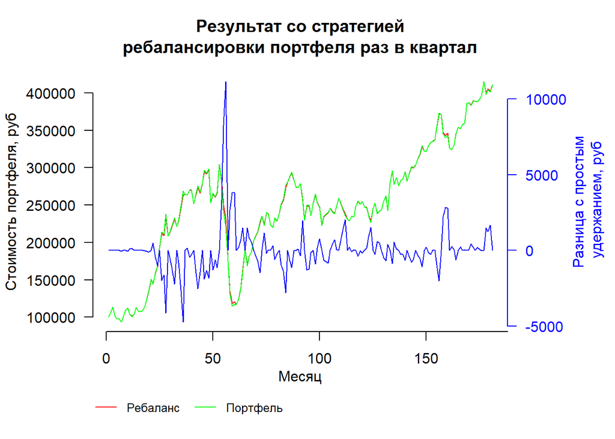

```r
result_r <- data.frame('Reb'= df[,6])
result_r$Vanila <- result$Portfolio
result_r$diff <- result_r$Reb - result_r$Vanila

par(mar=c(6, 5.2, 4, 6) + 0.1)
plot(result_r$Reb, type = 'l', col = 'red', axes = FALSE,
     main = 'Результат со стратегией\nребалансировки портфеля раз в квартал', xlab = "", ylab = "")
lines(result_r$Vanila, col = 'green')
axis(2, ylim = c(0, 500000), col = "black", col.axis = 'black', las = 1)
mtext("Стоимость портфеля, руб", side = 2, col = "black", line = 4.2)
par(new = TRUE)
plot(result_r$diff, type = 'l', col = 'blue', axes = FALSE, xlab="", ylab="")
axis(4, ylim = c(-16000, 16000), col = "blue", col.axis = "blue", las = 1)
mtext("Разница с простым\n удержанием, руб", side = 4, col = "blue", line = 4.5)
axis(1, pretty(index(result_r)))
mtext("Месяц", side = 1, col = "black", line = 2)
legend(x = -10, y = -9400, c("Ребаланс","Портфель"), cex=.8, col = c("red", "green"),
       lty = c(1, 1), box.lty=0,inset=c(0,1), xpd=TRUE, horiz=TRUE)
```

Рассчитаем стратегию с использованием ребалансировки раз в месяц:

```r
df <- data[,-c(4:5)]
df$MOEX <- df$MOEX / 100
df$Bond <- df$Bond / 100
for (i in 2:N){
  df$P_M[i] = df$P_M[i-1] * (1 + df$MOEX[i])
  df$P_B[i] = df$P_B[i-1] * (1 + df$Bond[i])
  df$Sum[i] = df$P_M[i] + df$P_B[i]
  df$P_M[i] = df$Sum[i] * Risk
  df$P_B[i] = df$Sum[i] * No_Risk
  df$Sum[i] = df$P_M[i] + df$P_B[i]
  df$MoexWeight[i] = df$P_M[i] / df$Sum[i]
  df$BondWeight[i] = df$P_B[i] / df$Sum[i]
}
```

Посмотрим на результат:

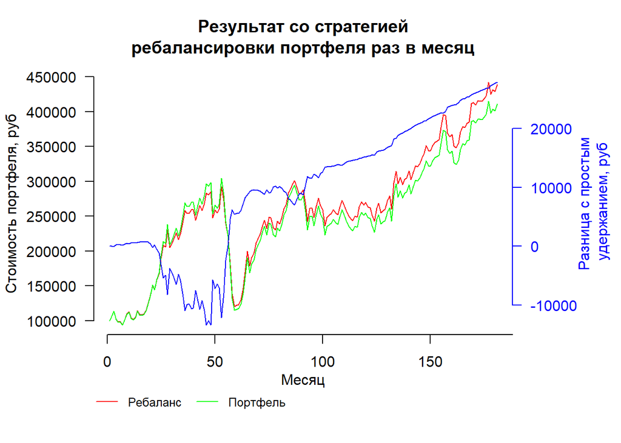

```r
result_r <- data.frame('Reb'= df[,6])
result_r$Vanila <- result$Portfolio
result_r$diff <- result_r$Reb - result_r$Vanila

par(mar=c(6, 5.2, 4, 6) + 0.1)
plot(result_r$Reb, type = 'l', col = 'red', axes = FALSE,
     main = 'Результат со стратегией\nребалансировки портфеля раз в месяц', xlab = "", ylab = "")
lines(result_r$Vanila, col = 'green')
axis(2, ylim = c(0, 500000), col = "black", col.axis = 'black', las = 1)
mtext("Стоимость портфеля, руб", side = 2, col = "black", line = 4.2)
par(new = TRUE)
plot(result_r$diff, type = 'l', col = 'blue', axes = FALSE, xlab="", ylab="")
axis(4, ylim = c(-40000, 40000), col = "blue", col.axis = "blue", las = 1)
mtext("Разница с простым\n удержанием, руб", side = 4, col = "blue", line = 4.5)
axis(1, pretty(index(result_r)))
mtext("Месяц", side = 1, col = "black", line = 2)
legend(x = -10, y = -24000, c("Ребаланс","Портфель"), cex=.8, col = c("red", "green"),
       lty = c(1, 1), box.lty=0,inset=c(0,1), xpd=TRUE, horiz=TRUE)
```

Расчитаем портфели:

```r
N <- nrow(data)
for (i in 2:N) {
  data$Moex_add[i] = data$Moex_add[i-1] *(1 + (data$MOEX[i] / 100))
  data$Bond_add[i] = data$Bond_add[i-1] *(1 + (data$Bond[i] / 100))
}

portfolio <- 100000

this <- 1
another <- 1 - this
col_num <- 1
temp <- data
point <- 1
numer <- 60
new_name <- 1
data_name <- character()

while (numer < nrow(temp)) {
  data <- temp[c(point:numer),]
  data$Moex_add[1] <- 1
  data$Bond_add[1] <- 1
  N <- nrow(data)
  for (i in 2:N) {
    data$Moex_add[i] = data$Moex_add[i-1] *(1 + (data$MOEX[i] / 100))
    data$Bond_add[i] = data$Bond_add[i-1] *(1 + (data$Bond[i] / 100))
  }
  data$P_M <- 0
  data$P_B <- 0

  this <- 1
  another <- 1 - this
  col_num <- 1
  output <- data.frame(num = rep(NA, 21),
                       moexW = 0,
                       BondW = 0,
                       result_vanila = 0,
                       result_year = 0,
                       result_quarter = 0,
                       result_month = 0)

  output <- output[,-1]
  while (another < 1.05) {
    Risk <- this
    No_Risk <- another
    portfolio_a <- portfolio * Risk
    portfolio_p <- portfolio * No_Risk
    # Стратегия удержание
    data$P_M <- data$Moex_add * portfolio_a
    data$P_B <- data$Bond_add * portfolio_p
    data$Sum <- data$P_M + data$P_B
    data$MoexWeight <- data$P_M / data$Sum
    data$BondWeight <- data$P_B / data$Sum
    output$moexW[col_num] = percent(Risk)
    output$BondW[col_num] = percent(No_Risk)
    output$result_vanila[col_num] = data$Sum[nrow(data)]

    ## Стратегия с использованием ребалансировки раз в год
    df <- data[,-c(4:5)]
    df$Signal <- 0
    N <- nrow(df)
    for (i in 2:N) {df$Signal[i] = ifelse(df$Year[i] == df$Year[i-1], 0, 1)}
    df$MOEX <- df$MOEX / 100
    df$Bond <- df$Bond / 100
    for (i in 2:N){
      if(df$Signal[i] == 1){
        df$P_M[i] = df$P_M[i-1] * (1 + df$MOEX[i])
        df$P_B[i] = df$P_B[i-1] * (1 + df$Bond[i])
        df$P_M[i] = df$Sum[i] * Risk
        df$P_B[i] = df$Sum[i] * No_Risk
        df$MoexWeight[i] = df$P_M[i] / df$Sum[i]
        df$BondWeight[i] = df$P_B[i] / df$Sum[i]
      } else {
        df$P_M[i] = df$P_M[i-1] * (1 + df$MOEX[i])
        df$P_B[i] = df$P_B[i-1] * (1 + df$Bond[i])
        df$Sum[i] = df$P_M[i] + df$P_B[i]
        df$MoexWeight[i] = df$P_M[i] / df$Sum[i]
        df$BondWeight[i] = df$P_B[i] / df$Sum[i]
      }
    }
    output$result_year[col_num] <- df$Sum[nrow(df)]
    rm(df)

    ## Стратегия с использованием ребалансировки раз в квартал
    df <- data[,-c(4:5)]
    df$Signal <- 0
    df[seq(1, nrow(df), 4), 9] <- 1
    df$MOEX <- df$MOEX / 100
    df$Bond <- df$Bond / 100
    for (i in 2:N){
      if(df$Signal[i] == 1){
        df$P_M[i] = df$P_M[i-1] * (1 + df$MOEX[i])
        df$P_B[i] = df$P_B[i-1] * (1 + df$Bond[i])
        df$P_M[i] = df$Sum[i] * Risk
        df$P_B[i] = df$Sum[i] * No_Risk
        df$MoexWeight[i] = df$P_M[i] / df$Sum[i]
        df$BondWeight[i] = df$P_B[i] / df$Sum[i]
      } else {
        df$P_M[i] = df$P_M[i-1] * (1 + df$MOEX[i])
        df$P_B[i] = df$P_B[i-1] * (1 + df$Bond[i])
        df$Sum[i] = df$P_M[i] + df$P_B[i]
        df$MoexWeight[i] = df$P_M[i] / df$Sum[i]
        df$BondWeight[i] = df$P_B[i] / df$Sum[i]
      }
    }
    output$result_quarter[col_num] <- df$Sum[nrow(df)]
    rm(df)

    ## Стратегия с использованием ребалансировки раз в месяц
    df <- data[,-c(4:5)]
    df$MOEX <- df$MOEX / 100
    df$Bond <- df$Bond / 100
    for (i in 2:N){
      df$P_M[i] = df$P_M[i-1] * (1 + df$MOEX[i])
      df$P_B[i] = df$P_B[i-1] * (1 + df$Bond[i])
      df$Sum[i] = df$P_M[i] + df$P_B[i]
      df$P_M[i] = df$Sum[i] * Risk
      df$P_B[i] = df$Sum[i] * No_Risk
      df$Sum[i] = df$P_M[i] + df$P_B[i]
      df$MoexWeight[i] = df$P_M[i] / df$Sum[i]
      df$BondWeight[i] = df$P_B[i] / df$Sum[i]
    }
    output$result_month[col_num] <- df$Sum[nrow(df)]
    col_num <- col_num + 1
    this <- this - .05
    another <- 1 - this
  }
  output$moexW <- round(output$moexW, digits = 2)
  data_name <- c(data_name, paste('data_massiv', '_', new_name, sep = ''))
  assign(paste('data_massiv', '_', new_name, sep = ''), output)
  rm(output, df)
  new_name <- new_name + 1
  point <- point + 12
  numer <- numer + 12

}
```

Построим графики этих портфелей:

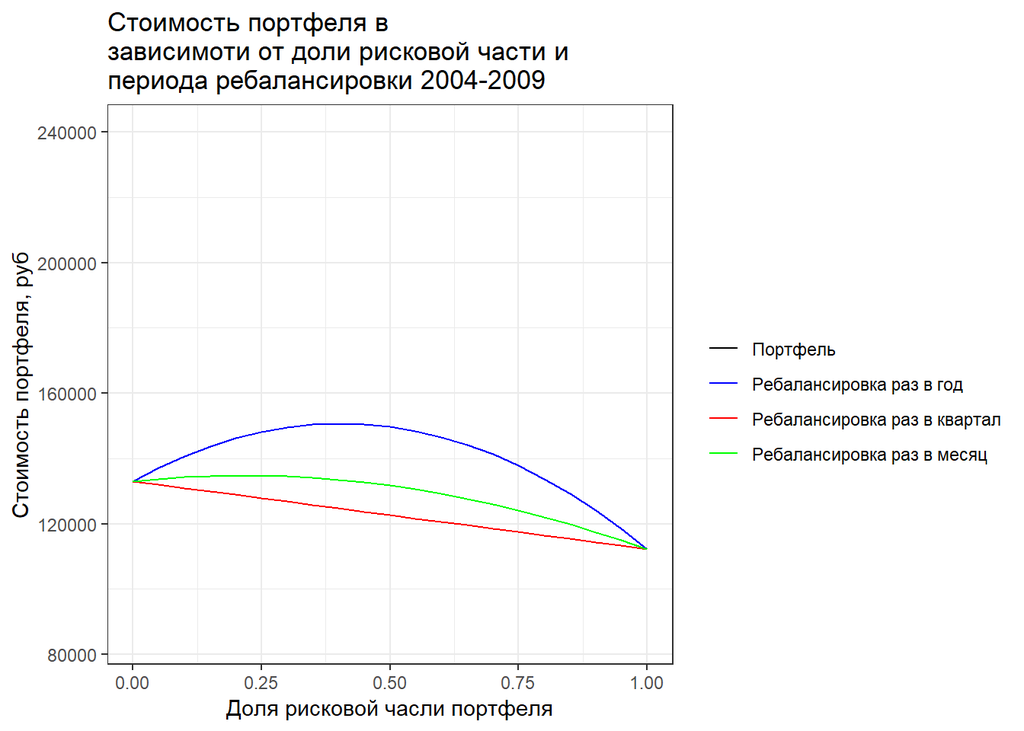

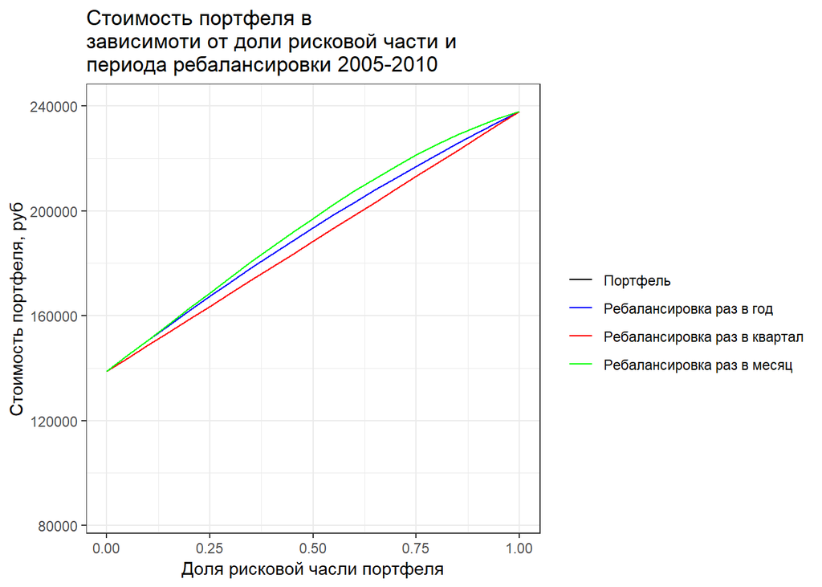

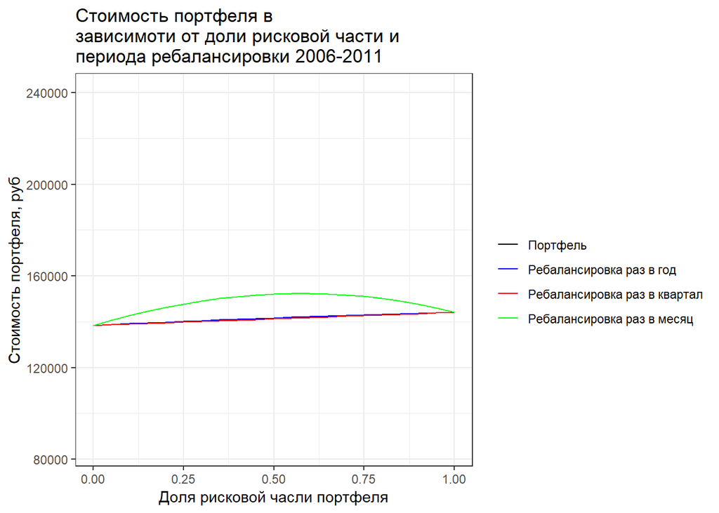

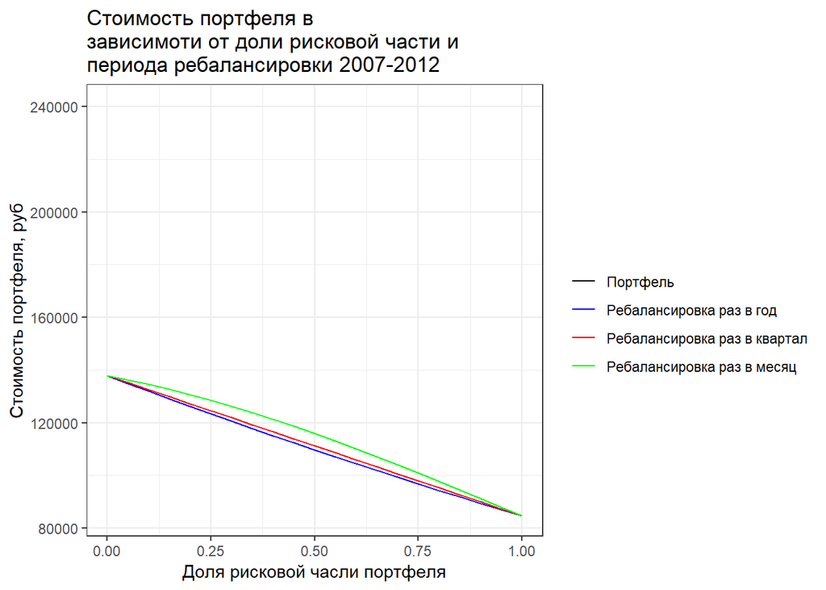

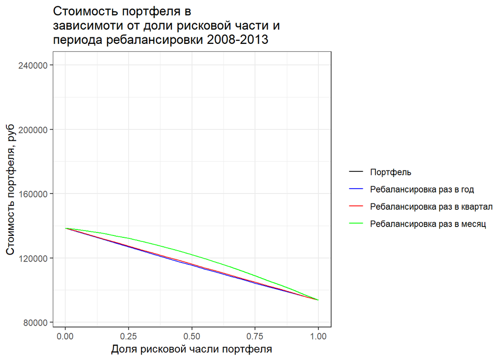

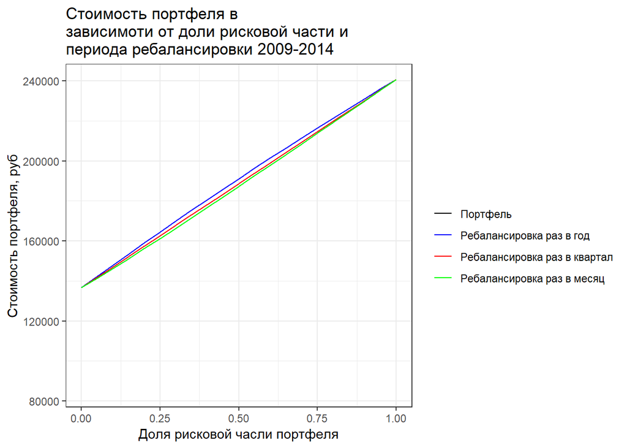

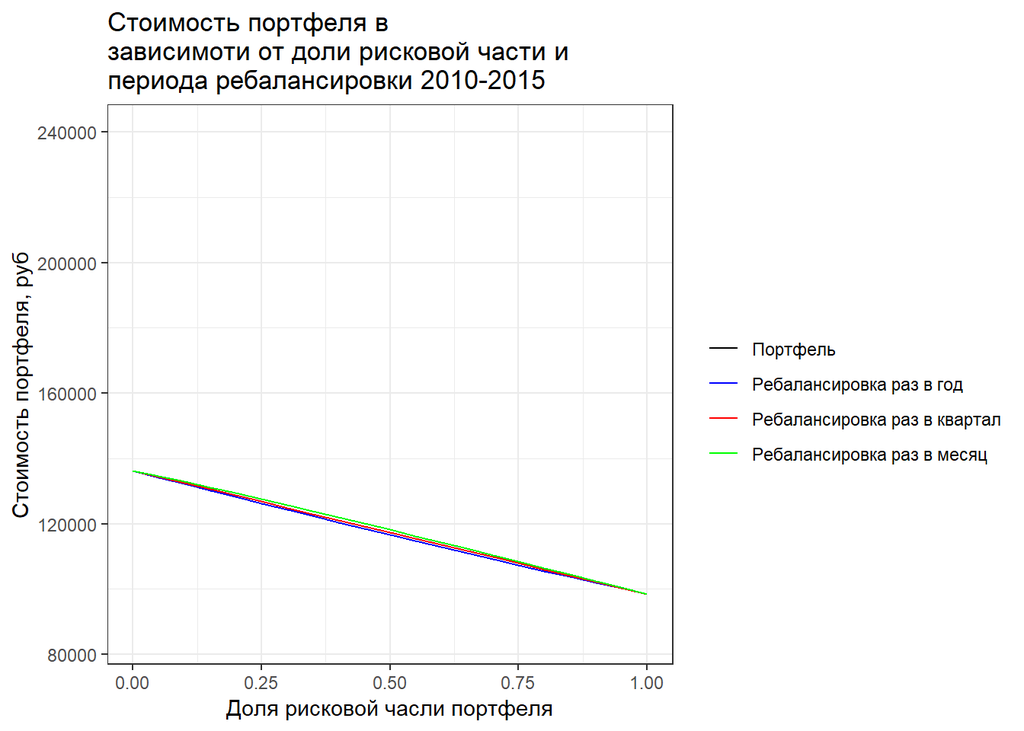

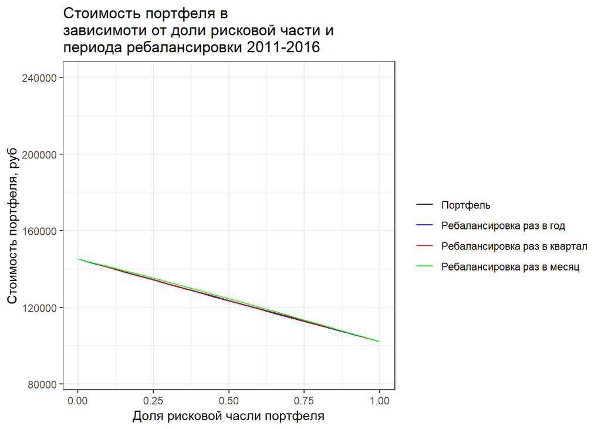

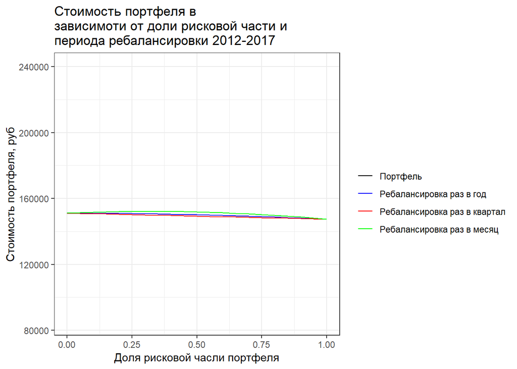

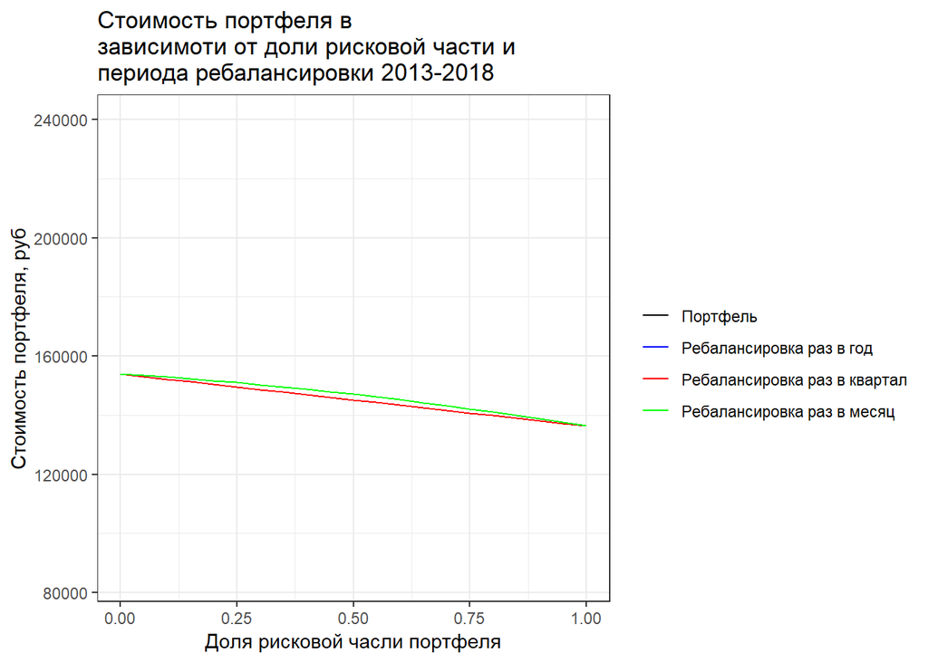

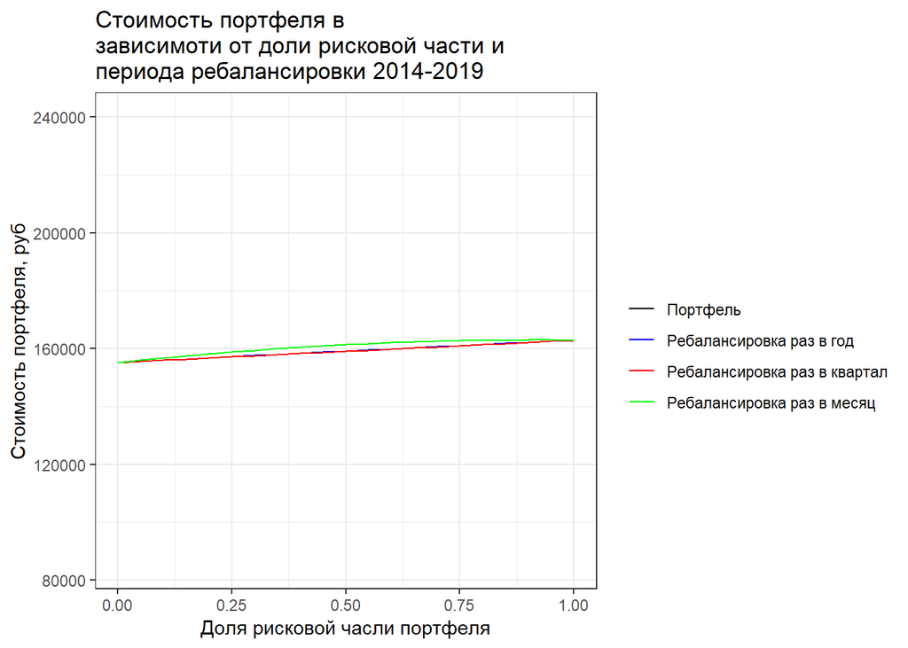

```r
start <- 2004
finish <- start + 5
plots <- data_massiv_1
plots$Simbol <- paste(start, '-', finish, sep = '')

a <- 1
b <- nrow(plots)

for(i in data_name[-1]){
  y <- get(i)
  start <- start + 1
  finish <- start + 5
  a = a + 21
  b = b + 21
  plots[a:b,] = y[1:21,]
  plots[a:b,7] = paste(start, '-', finish, sep = '')
  plots[a:b,8] = start
}

library(gganimate)
theme_set(theme_bw())
pl <- ggplot(plots, aes(x = plots$moexW, frame = plots$Simbol))
pl <- pl + geom_line(aes(y = plots$result_vanila, colour = 'vanila'))
pl <- pl + geom_line(aes(y = plots$result_year, colour = 'year'))
pl <- pl + geom_line(aes(y = plots$result_quarter, colour = 'quarter'))
pl <- pl + geom_line(aes(y = plots$result_month, colour = 'month'))
pl <- pl + xlab("Доля рисковой часли портфеля")
pl <- pl + ylab("Стоимость портфеля, руб")
pl <- pl + labs(title = 'Стоимость портфеля в \nзависимоти от доли рисковой части и \nпериода ребалансировки')
pl <- pl + scale_colour_manual("",
                      breaks = c('vanila', 'year', 'quarter', 'month'),
                      values = c("green","red", "black", "blue"),
                      labels=c('Портфель',
                               'Ребалансировка раз в год',
                               'Ребалансировка раз в квартал',
                               'Ребалансировка раз в месяц'))

gganimate::gg_animate(pl, interval = 1)
```

Графики показывают сильный разброс результата. Для выбора ориетировочного портфеля (Benchmark) требуется проанализировать портфели по другим характеристикам.